# DATA 550 Lab 3 - Communication visualizations

### Question 2.3

rubric={viz:2}

#### R

Improve my ggplot plot. Chose the best type of plot to accurately reveal what the data looks like. Design the plot to be an effective plot for communication purposes, this includes proper figure size, axis/figure titles, font sizes, colors, etc. You can either make a single or several plots, depending on what you think is needed.

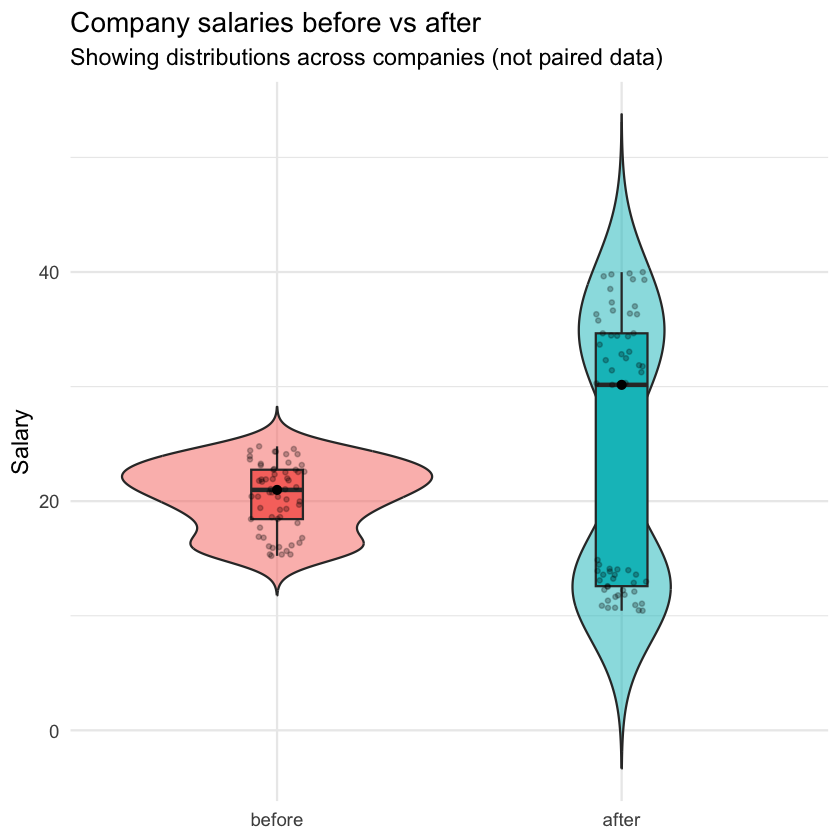

```r
library(tidyverse)
library(scales)

wages <- read.csv("wages.csv")
wages$when <- factor(wages$when, levels = c("before", "after"))

ggplot(wages, aes(x = when, y = salary, fill = when)) +
  geom_violin(trim = FALSE, alpha = 0.5) +
  geom_boxplot(width = 0.15, outlier.alpha = 0.3) +
  geom_jitter(width = 0.08, alpha = 0.25, size = 1) +
  stat_summary(fun = median, geom = "point", size = 2, color = "black") +
  labs(
    title = "Company salaries before vs after",
    subtitle = "Showing distributions across companies (not paired data)",
    x = NULL,
    y = "Salary"
  ) +
  theme_minimal(base_size = 14) +
  theme(legend.position = "none")
```

# 3. Guns to the people

## The data

The `guns-r-us.csv` dataset contains yearly data for the number of murders by firearms in Florida.

[figure not shown]

## My plots

### ggplot

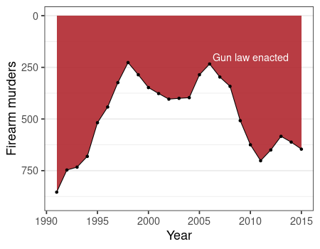

## My claim

As you can see, just after the gun law in Florida was enacted, deaths from firearms plummeted. I don't really think there is much else to discuss here.

### Question 3.1

rubric={reasoning:2,writing:1}

- Explain which mistakes (if any) I have done in my plot and provide an interpretation of the data that is more correct than mine. Be brief and clear in your answer.
- You might have some ideas just from looking at my plot, but you will likely need to do some investigation yourself to answer this question fully. You can reference your improved plot as needed.

The plot also ignores longer-term trends and natural year-to-year variation. Firearm murders were already fluctuating before 2005, and similar changes occur after the law without a consistent downward pattern.

### Question 3.2

rubric={accuracy:2}

#### R

Recreate my ggplot version of the plot. Your plot should look as close as possible to mine in the image above.

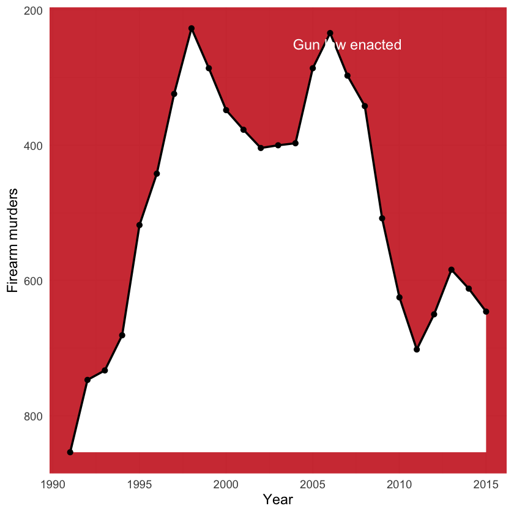

```r
library(ggplot2)

guns <- read.csv("guns-r-us.csv")

ggplot(guns, aes(x = Year, y = Firearm.murders)) +
  annotate("rect",
           xmin = -Inf, xmax = Inf,
           ymin = -Inf, ymax = Inf,
           fill = "firebrick3", alpha = 0.9) +
  geom_ribbon(aes(ymin = Firearm.murders, ymax = max(Firearm.murders)),
              fill = "white") +
  geom_line(color = "black", linewidth = 1) +
  geom_point(color = "black", size = 2) +
  annotate("text",
           x = 2007, y = 250,
           label = "Gun law enacted",
           color = "white", size = 5) +
  scale_y_reverse() +
  labs(x = "Year", y = "Firearm murders") +
  theme_minimal(base_size = 14)
```

### Question 3.3

rubric={viz:2}

#### R

Improve my ggplot plot. Chose the best type of plot to accurately reveal what the data looks like. Design the plot to be an effective plot for communication purposes, this includes proper figure size, axis/figure titles, font sizes, colors, etc.

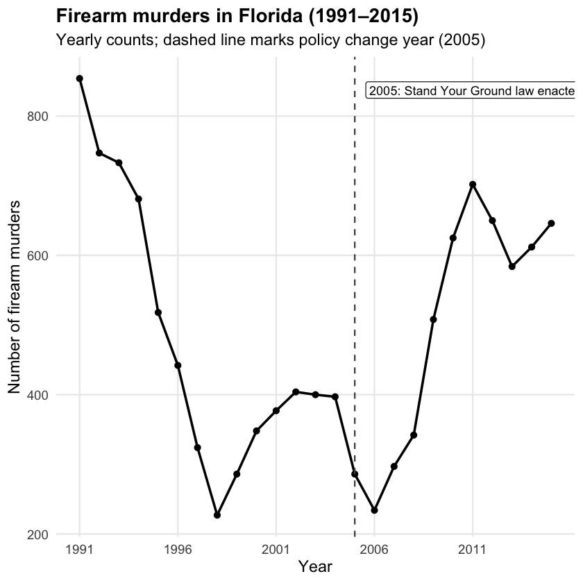

```r
library(tidyverse)

guns <- read.csv("guns-r-us.csv")

ggplot(guns, aes(x = Year, y = Firearm.murders)) +
  geom_line(linewidth = 1) +
  geom_point(size = 2) +

  geom_vline(xintercept = 2005, linetype = "dashed", color = "grey30") +
  annotate("label",
           x = 2005, y = max(guns$Firearm.murders),
           label = "2005: Stand Your Ground law enacted",
           hjust = -0.05, vjust = 1.2,
           size = 3.8, label.size = 0,
           fill = "white") +

  labs(
    title = "Firearm murders in Florida (1991–2015)",
    subtitle = "Yearly counts; dashed line marks policy change year (2005)",
    x = "Year",
    y = "Number of firearm murders"
  ) +

  scale_x_continuous(breaks = seq(min(guns$Year), max(guns$Year), by = 5)) +
  theme_minimal(base_size = 14) +
  theme(
    plot.title = element_text(face = "bold"),
    panel.grid.minor = element_blank()
  )
```

# My approval ratings are astronomical

## The data

The (fictional) `state-comparison.csv` dataset contains a sample of voters from my state and a neighboring state of similar socioeconomic standard. Voters in each state were asked to rate their approval of the state's mayor on a scale from 0 - 10,000.

## My plots

### ggplot

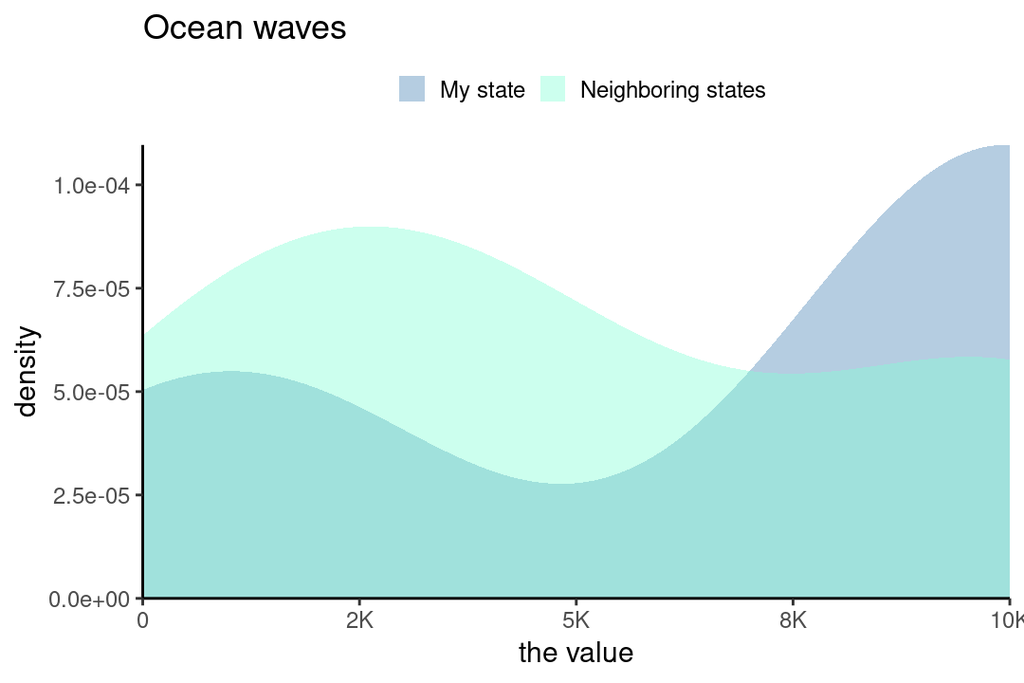

## My claim

My approval ratings are through the roof! I am clearly doing a better job than my colleague and competitor next doors. And as you can see we sampled enough people to get smooth curves, which means that this difference is both likely to be statistically significant and the magnitude is just too big to ignore. There seems to be a few bores on the lower end of the spectrum, but can't win them all I guess. Do you want a 10k approval rating future?

### Question 4.1

rubric={reasoning:2,writing:1}

- Explain which mistakes (if any) I have done in my plot and provide an interpretation of the data that is more correct than mine. Be brief and clear in your answer.
- You might have some ideas just from looking at my plot, but you will likely need to do some investigation yourself to answer this question fully. You can reference your improved plot as needed.

The main issue with this plot is that it uses smoothed density curves, which can be misleading. Density plots normalize the area to one, so they do not reflect sample size, and smoothness does not imply statistical significance.

In addition, the strong smoothing may hide important features of the raw data. The wide x-axis range (0–10000) also exaggerates small differences between the states.

Furthermore, no summary statistics (such as means, medians, or sample sizes) are shown, making it difficult to assess the practical significance.

### Question 4.2

rubric={accuracy:2}

#### R

Recreate my ggplot version of the plot. Your plot should look as close as possible to mine in the image above.

```r
states <- read.csv("state-comparison.csv")
```

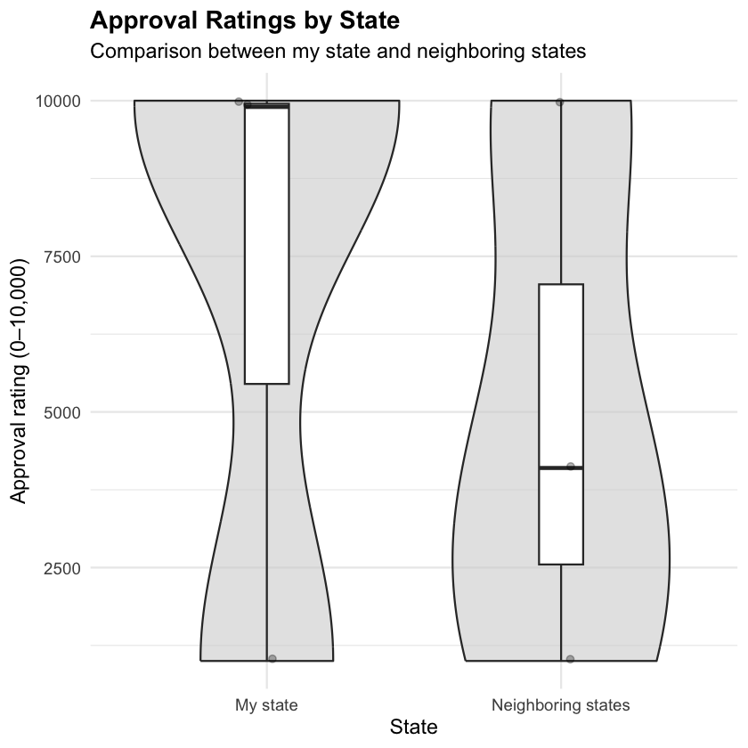

```r
states <- read.csv("state-comparison.csv")
ggplot(states, aes(x = where, y = the.value)) +
  geom_violin(fill = "lightgray", alpha = 0.6) +
  geom_boxplot(width = 0.15, outlier.shape = NA) +
  geom_jitter(width = 0.1, alpha = 0.3) +
  labs(
    title = "Approval Ratings by State",
    subtitle = "Comparison between my state and neighboring states",
    x = "State",
    y = "Approval rating (0–10,000)"
  ) +
  theme_minimal(base_size = 14) +
  theme(
    plot.title = element_text(face = "bold"),
    legend.position = "none"
  )
```

### Question 4.3 (Optional)

rubric={viz:1}

#### R

Improve my ggplot plot. Chose the best type of plot to accurately reveal what the data looks like. Design the plot to be an effective plot for communication purposes, this includes proper figure size, axis/figure titles, font sizes, colors, etc.

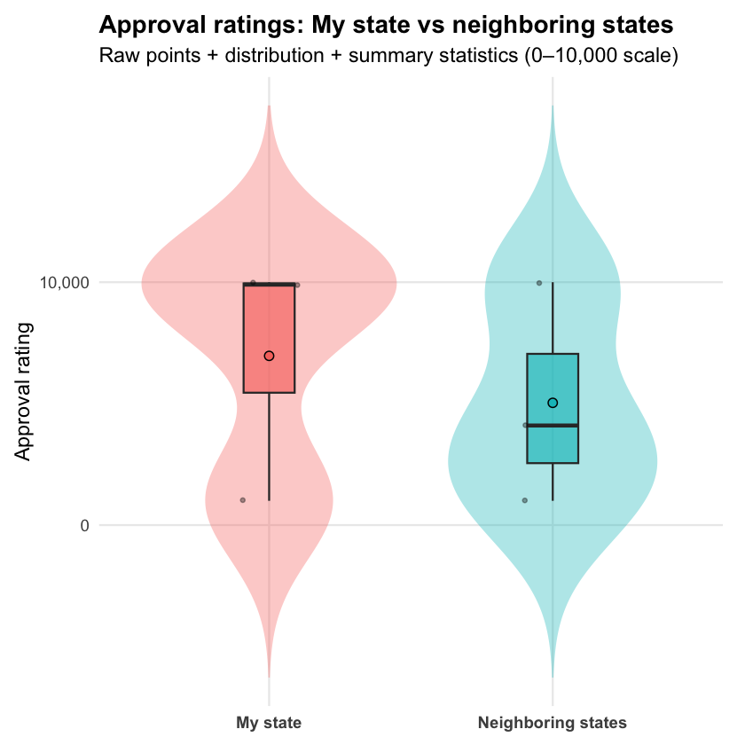

```r
library(ggplot2)

states$where <- factor(states$where, levels = c("My state", "Neighboring states"))

ggplot(states, aes(x = where, y = the.value, fill = where)) +
  geom_violin(trim = FALSE, alpha = 0.35, color = NA) +
  geom_boxplot(width = 0.18, outlier.shape = NA, alpha = 0.65) +
  geom_jitter(width = 0.10, alpha = 0.35, size = 1) +
  stat_summary(fun = mean, geom = "point", size = 2.5, shape = 21, color = "black") +
  labs(
    title = "Approval ratings: My state vs neighboring states",
    subtitle = "Raw points + distribution + summary statistics (0–10,000 scale)",
    x = NULL,
    y = "Approval rating"
  ) +
  scale_y_continuous(labels = scales::comma) +
  guides(fill = "none") +
  theme_minimal(base_size = 14) +
  theme(
    plot.title = element_text(face = "bold"),
    axis.text.x = element_text(face = "bold"),
    panel.grid.minor = element_blank(),
    plot.margin = margin(10, 15, 10, 10)
  )
```

### Question 5 (Optional)

rubric={viz:0.5,reasoning:0.5}

#### R or Python

Pick a existing ggplot or Altair chart and improve at least 3 different communication related aspects of this plot that we have discussed in lectures. In addition, show your proficiency in reading the documentation and looking for help online, by finding one communication related parameter that we have not discussed in lectures and use it to improve the visuals of the plot (it is also ok to use an option that we haven’t discussed of a parameter that we have discussed).

1. Paste in the code of the existing plot you picked and run it so that we can see what the original looked like. Include the URL to the original plot as a comment in the code cell.
   - You can take any plot you want! As long as you can find the source code and paste it here (and it is not copyright protected). There are suggestions for [ggplot here](https://www.r-graph-gallery.com/) and [Altair here](https://altair-viz.github.io/gallery/index.html).
2. In a new cell, make your modifications and plot the improved chart.
3. Briefly describe the changes you made and why they make this plot more suitable for communication. Explicitly mention which new parameter/option you picked that we have not discussed before and why you picked it.

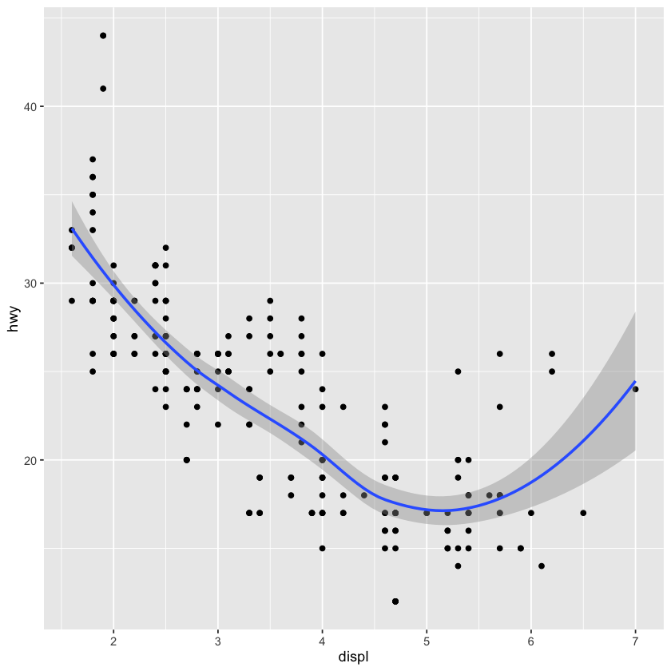

```r
ggplot(mpg, aes(displ, hwy)) +
  geom_point() +
  geom_smooth(method = "loess")
```

[output not shown]

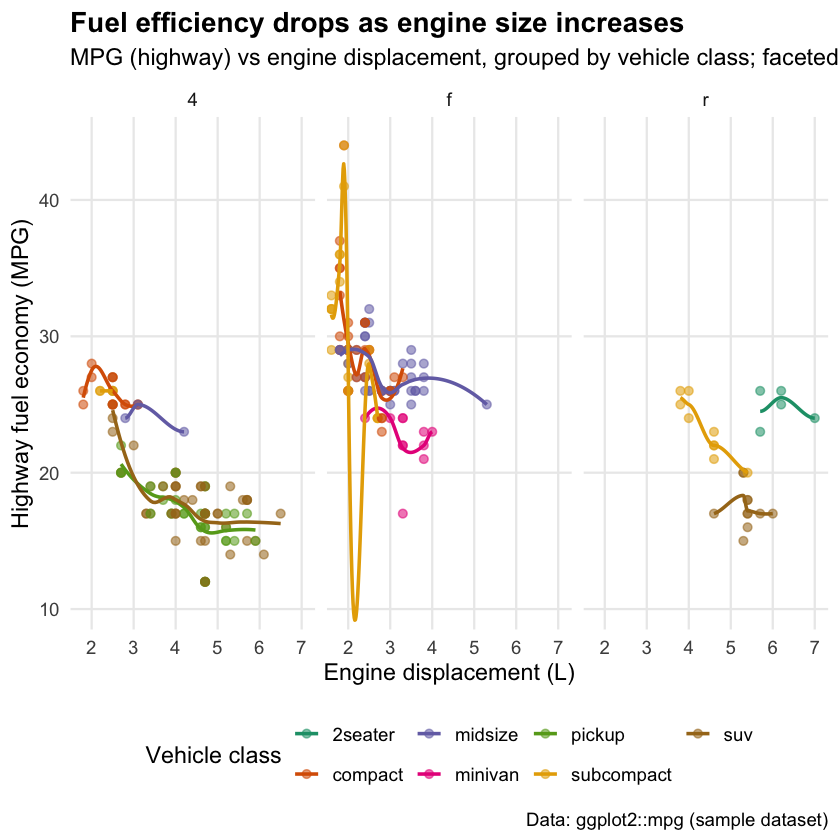

```r
library(ggplot2)

ggplot(mpg, aes(x = displ, y = hwy, color = class)) +
  geom_point(alpha = 0.55, size = 2) +
  geom_smooth(se = FALSE, linewidth = 1) +
  facet_wrap(~ drv, nrow = 1) +
  labs(
    title = "Fuel efficiency drops as engine size increases",
    subtitle = "MPG (highway) vs engine displacement, grouped by vehicle class; faceted by drivetrain",
    x = "Engine displacement (L)",
    y = "Highway fuel economy (MPG)",
    color = "Vehicle class",
    caption = "Data: ggplot2::mpg (sample dataset)"
  ) +
  scale_color_brewer(palette = "Dark2") +
  scale_x_continuous(expand = expansion(mult = c(0.02, 0.06))) +
  scale_y_continuous(expand = expansion(mult = c(0.02, 0.06))) +
  theme_minimal(base_size = 14) +
  theme(
    plot.title = element_text(face = "bold"),
    legend.position = "bottom",
    panel.grid.minor = element_blank()
  )
```

I improved the plot by adding clear titles, axis labels, and a caption so that readers can easily understand what the chart shows and where the data comes from. I used color and transparency to distinguish different vehicle classes and reduce overplotting. I also used faceting to separate different drivetrain types, which makes comparisons clearer.

In addition, I applied a color-blind friendly palette to improve readability. I used the expand = expansion() option in scale_x_continuous() and scale_y_continuous() to control axis padding, which prevents points and lines from touching the edges and makes the plot look more professional and easier to read.

Ready to submit? I hope you had a favorable view of my data interpretations or there might be trouble coming your way in lab4...

# Submission to Canvas

When you are ready to submit your assignment do the following:

1. Run all cells in your notebook to make sure there are no errors by doing `Kernel -> Restart Kernel and Run All Cells...`
2. Commit and push all your work (including the .ipynb file) to GitHub.
3. Submit a link to your repo on Canvas (this has to be done only once per group).